# Comparison of variation of expression level between regimes

J. Ignacio Lucas Lledó

28/1/2020

# Introduction

```r
library(variancePartition)
library(ggplot2)
library(tidyr)
library(reactable)
library(BiocParallel)
library(edgeR)

EXPRESSION <- '../2020-01-08/genes.RData'   # variance partition and the mixed models fitted with dream()
COUNTS <- '../2019-03-29/genes.PostCount.txt'
NUM_THREADS <- 40
```

One obvious expectation that I have not tested yet is that resting eggs under an unpredictable environment should also have a more *random*, noiser, or unpredictable gene expression. That is, gene expression levels should vary more among eggs laid in unpredictable environments. To put it another way, in perfectly regular environments, eggs are expected to resemble more each other in terms of gene expression patters. Gene expression should be less variable among eggs in regular than in unpredictable environments.

We did not measure expression levels in single cells. But the variance of expression levels among individual cells contributes to the observed variance among samples, from which the mean-variance relationshps were estimated. The `variancePartition` package does not include a function to plot the estimated mean-variance relationship. That relationship is used to impute the variance of every single mesurement of expression level in every sample. The inverse of that imputed variance is stored in the `EList` object created with the `voomWithDreamWeights()` function, that I named `vobjDream`.

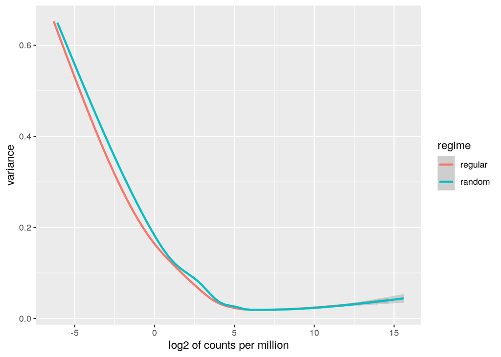

```r
load(EXPRESSION)
colnames(vobjDream$E)       <- paste('expression', row.names(vobjDream$targets), sep='_')
colnames(vobjDream$weights) <- paste('variance', row.names(vobjDream$targets), sep='_')
meanVar <- as.data.frame(cbind(vobjDream$E, 1/vobjDream$weights))
meanVar$gene <- row.names(meanVar)    # column 25
meanVar <- pivot_longer(meanVar, cols=1:24, names_to=c('what','population','hatching'),
                        names_pattern='(expression|variance)_(X[1-6])([AC])', values_to='value')
meanVar$regime <- factor('regular', levels=c('regular', 'random'))
meanVar[meanVar$population %in% c('X1', 'X2', 'X4'), 'regime'] <- 'random'
meanVar <- pivot_wider(meanVar, names_from='what', values_from='value')
ggplot(data=meanVar, mapping=aes(x=expression, y=variance, color=regime)) +
  geom_smooth() + xlab('log2 of counts per million')
```

Yes, eggs have more variable expression levels in unpredictable environments. The difference is not that big, actually. It makes me think that heteroscedasticity may not be properly taken into account. Even though variance is modelled at the observation level, variances of individual observations are predicted from the mean-variance trend estimated from gene-wise mean expression levels and residual standard deviations (from gene-wise linear fits) (“Voom: Precision Weights Unlock Linear Model Analysis Tools for RNA-Seq Read Counts” 2014). That is, the variance predictions are informed by the expression level expected under a gene-wise linear model. Such models do include the effects of all variables. However, I don’t think the systematic effect of the selective regime in gene expression variance is taken into account.

# Separate estimation of variances for each selective regime

Let’s see what happens if I fit a simpler model to each regime separately. Below I separate the samples by selective regime. However, I do not apply a regime-specific filter. Instead, I use the same genes that had been selected before, for the whole dataset analysis. This has the undesired effect of introducing very log expression genes in both subsets of samples (I think more so in those from the unpredictable environment). But I want to make sure I’m using the same subset of genes in both split analyses and in the original one. That way, I will be able to use the newly estimated weights with the original model in the whole data set.

```r
counts <- as.matrix(read.table(COUNTS, row.names=1, header=TRUE))
threshold <- 5 / (min(colSums(counts)) / 1000000)
keep <- rowSums(cpm(counts) > threshold) >= 4
## Also tried with a more restrictive filter: at least 2 samples with over-threshold expression levels in each subset
## (17225 genes). Results are very similar.
#keep <- rowSums(cpm(counts[,c(1,2,3,4,7,8)]) > threshold) >= 2 & rowSums(cpm(counts[,c(5,6,9,10,11,12)]) > threshold) >= 2

# samples:                 1A 1C 2A 2C 3A 3C 4A 4C 5A 5C 6A 6C
countsRandom  <- counts[keep,c( 1, 2, 3, 4,       7, 8            )]
countsRegular <- counts[keep,c(             5, 6,       9,10,11,12)]
geneExprRandom  <- DGEList(countsRandom)
geneExprRandom  <- calcNormFactors(geneExprRandom)
geneExprRegular <- DGEList(countsRegular)
geneExprRegular <- calcNormFactors(geneExprRegular)

metadataRandom  <- data.frame(row.names  = c("X1A_S8", "X1C_S1", "X2A_S7", "X2C_S5", "X4A_S6", "X4C_S12"),
                              population = factor(as.character(c(1,1,2,2,3,3)), levels=c('1','2','3')),
                              treatment  = c(0, 1, 0, 1, 0, 1),
                              treatmentChar = factor(c('hatch','diapause','hatch','diapause','hatch','diapause')))
metadataRegular <- data.frame(row.names  = c("X3A_S9", "X3C_S11", "X5A_S2", "X5C_S4", "X6A_S3", "X6C_S10"),
                              population = factor(as.character(c(1,1,2,2,3,3)), levels=c('1','2','3')),
                              treatment  = c(0, 1, 0, 1, 0, 1),
                              treatmentChar = factor(c('hatch','diapause','hatch','diapause','hatch','diapause')))

form <- ~ treatment + (1|population)

param = SnowParam(NUM_THREADS, "SOCK")
register(param)

## Weights
weightsRandom  <- voomWithDreamWeights(geneExprRandom,  form, metadataRandom)
weightsRegular <- voomWithDreamWeights(geneExprRegular, form, metadataRegular)
```

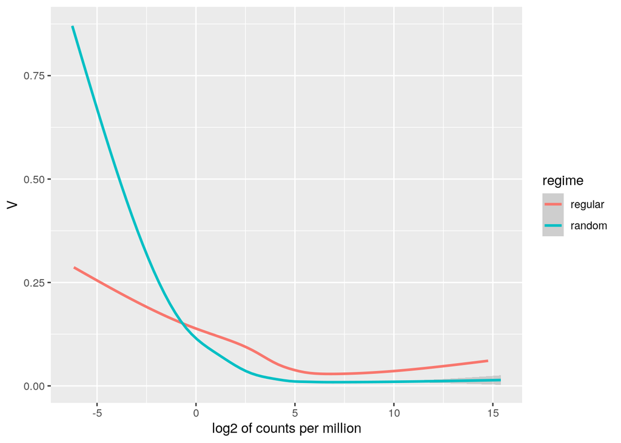

```r
E <- cbind(weightsRandom$E, weightsRegular$E)[,c(1,2,3,4,7,8,5,6,9,10,11,12)]
W <- cbind(weightsRandom$weights, weightsRegular$weights)[,c(1,2,3,4,7,8,5,6,9,10,11,12)]
colnames(E) <- paste('E', row.names(vobjDream$targets), sep='_')
colnames(W) <- paste('V', row.names(vobjDream$targets), sep='_')
meanVarSep  <- as.data.frame(cbind(E, 1/W))
meanVarSep$gene <- row.names(E)    # column 25
meanVarSep <- pivot_longer(meanVarSep, cols=1:24, names_to=c('what','population','hatching'),
                           names_pattern='([EV])_(X[1-6])([AC])', values_to='value')
meanVarSep$regime <- factor('regular', levels=c('regular', 'random'))
meanVarSep[meanVarSep$population %in% c('X1', 'X2', 'X4'), 'regime'] <- 'random'
meanVarSep <- pivot_wider(meanVarSep, names_from='what', values_from='value')
ggplot(data=meanVarSep, mapping=aes(x=E, y=V, color=regime)) +
  geom_smooth() + xlab('log2 of counts per million')
```

Estimating the mean-variance relationship separately for samples from the two different environments does show different relationships. I expected samples from the unpredictable environment to have higher variance of expression level, in general. What I see is that only genes expressed at low levels have higher expression variance in unpredictable than in regular environments. It seems biologically meaningful: highly expressed genes are likely to perform constitutive functions in the dormant embryos, and there is no good reason to expect them to vary very much among eggs. Lowly expressed genes, on the other hand, may include a complement with secondary functions, much less functionally constrained to vary.

Can we argue that embryos adapt to unpredictable environments by varying the expression level of a set of low-expression genes? What are the biological functions of highly expressed genes? Are they common between environments? What about the low-expression ones? Also, does the different mean-variance relationships affect the differential expression analysis? Lets start with the last one.

# Variance partition with weights estimated separately for regular and unpredictable environments

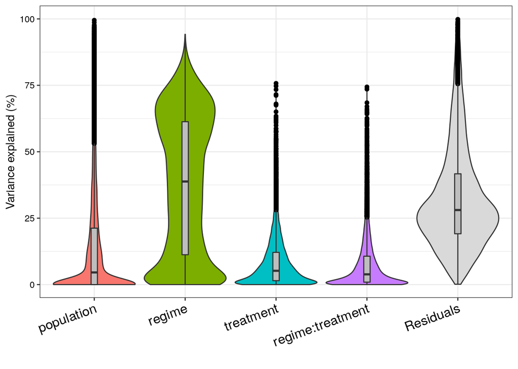

```r
# The expression matrix I use is the original one, in vobjDream$E, where all samples underwent
# a common normalization.
metadata <- data.frame(row.names = c("X1A_S8", "X1C_S1", "X2A_S7", "X2C_S5",
                                  "X3A_S9", "X3C_S11", "X4A_S6", "X4C_S12",
                                  "X5A_S2", "X5C_S4", "X6A_S3", "X6C_S10"),
                       regime = c(1, 1, 1, 1, 0, 0 , 1, 1, 0, 0, 0, 0),
                       regimeChar = c("random", "random", "random", "random",
                                  "regular", "regular", "random", "random",
                                  "regular", "regular", "regular", "regular"),
                       population = c("1", "1", "2", "2", "3", "3",
                                      "4", "4", "5", "5", "6", "6"),
                       treatment = rep(c(0, 1), 6),
                       treatmentChar = rep(c("hatch", "diapause"), 6))

form <- ~ regime + treatment + regime:treatment + (1|population)

varPartSep <- fitExtractVarPartModel(vobjDream$E[row.names(E),], form, metadata, weightsMatrix=W)
plotVarPart(varPartSep)
```

```r
fitmmSep <- dream(vobjDream$E[row.names(E),], form, metadata, weightsMatrix=W)
```

# References

“Voom: Precision Weights Unlock Linear Model Analysis Tools for RNA-Seq Read Counts.” 2014. *Genome Biology* 15: R19. doi:doi.org/10.1186/gb-2014-15-2-r29.